# MultiscaleDTM GeoHab 2022 Demo

# Purpose of Demo

This is a quick demo to show the utility of the `MultiscaleDTM` package for seafloor habitat mapping. It will show how you can calculate all five classes of terrain attributes (slope, aspect, curvature, rugosity, and relative position) at multiple different spatial scales with just a few lines of code. Then a simple unsupervised classification procedure is shown as an example of how these terrain attributes can be used in further analyses in R via connection to other R packages.

# Load package and data

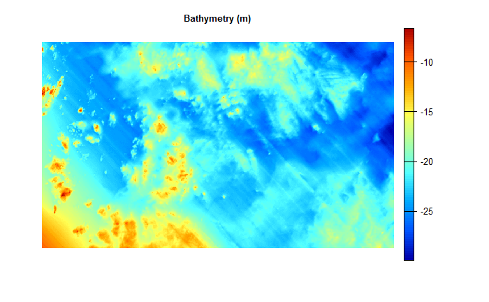

```r
library(MultiscaleDTM)

r<- rast("Data/bathy5m.tif")
plot(r, col= matlab.like(100), axes= FALSE, main = "Bathymetry (m)")
```

# Calculate terrain attributes at multiple scales

```r
w<- c(3, 5, 7, 11, 17, 27, 43, 69)  #Set window Sizes

TA<- rast() #Initialize multiband raster stack of terrain attributes
for (i in w) {
  SlpAspCurv<- Qfit(r, w = i, unit = "degrees", metrics = c("qslope", "qeastness", "qnorthness", "profc", "planc", "twistc", "meanc"), na.rm = TRUE, include_scale = TRUE)

  Rugosity<- AdjSD(r,w = i, na.rm = TRUE, include_scale = TRUE)

  RelativePosition<- TPI(r, w = i, na.rm = TRUE, include_scale = TRUE)

  TA<- c(TA, SlpAspCurv, Rugosity, RelativePosition) #Append to raster stack
}
```

```r
nlyr(TA) #Yay, you've calculated 72 terrain attributes!
```

```
[1] 72
```

# Unsupervised Classification

Unsupervised classification of raster data can be accomplished using the `RStoolbox` package.

```r
library(RStoolbox)
library(raster) #RStoolbox has not been fully upgraded to handle terra objects yet so we will need the raster package
```

## Principal Components Analysis

PCA allows us to represent our data in a lower number of dimensions while still maintaining a large proportion of the variance. Additionally unlike our original variables which may be collinear, all principal components are orthogonal (i.e. uncorrrelated).

```r
rPCA<- rasterPCA(raster::stack(TA), spca = TRUE, nSamples = NULL) #Run a standardized PCA (note: you have to convert to raster package object for RSToolbox)
```

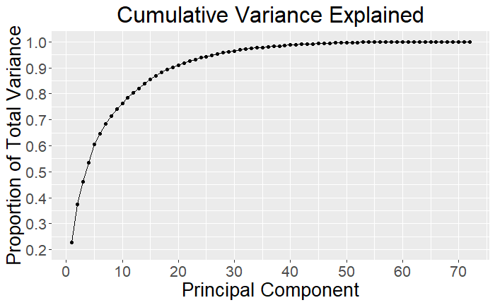

### Plot of First 20 Principal Components

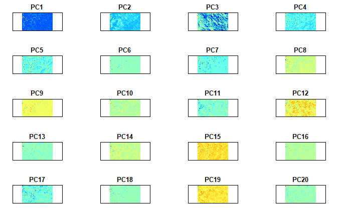

## Unsupervised Classification

Run unsupervised classification (k-means clustering) with five clusters on the first 20 principal components.

```r
set.seed(5) #Set random seed so that you get the same result each time
unsup<- unsuperClass(rPCA$map[[1:20]], nClasses = 5, algorithm="MacQueen", clusterMap = FALSE)
```

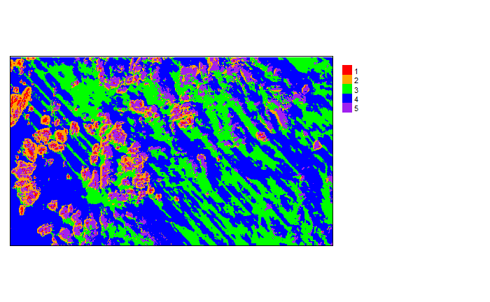